# California Barred Sand Bass

# Historical Simulation Plots

## Historical Time-Series

### Spawning Biomass

#### Depletion

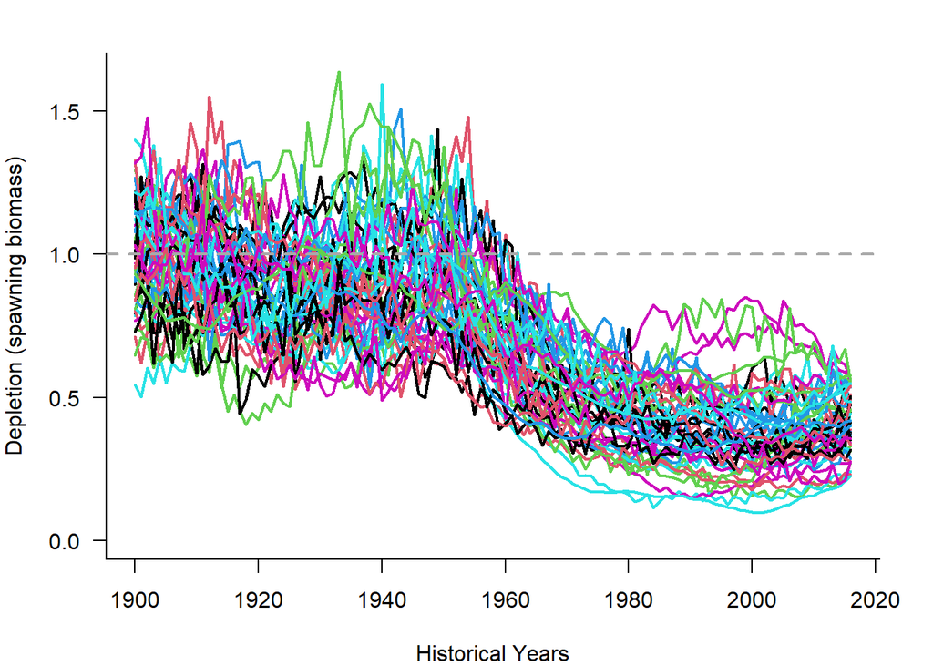

#### Absolute

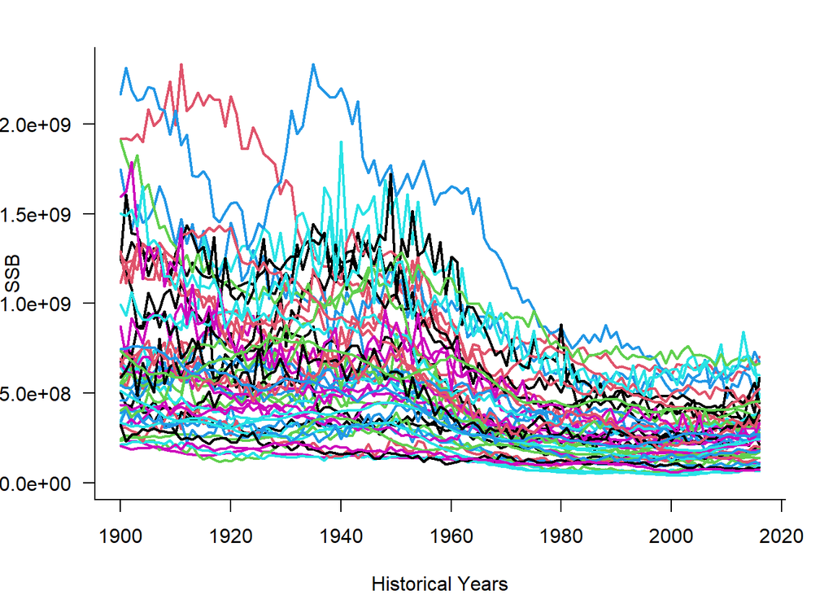

### Vulnerable Biomass

#### Depletion

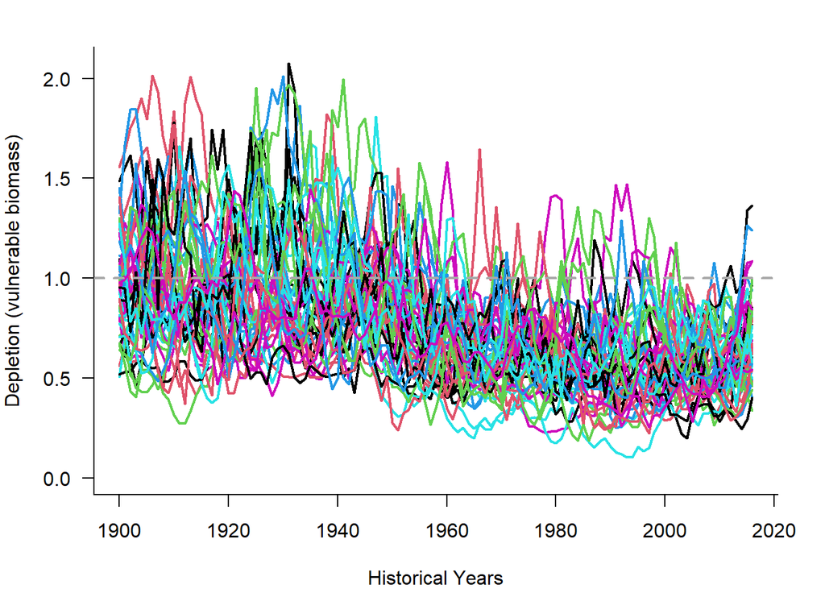

#### Absolute

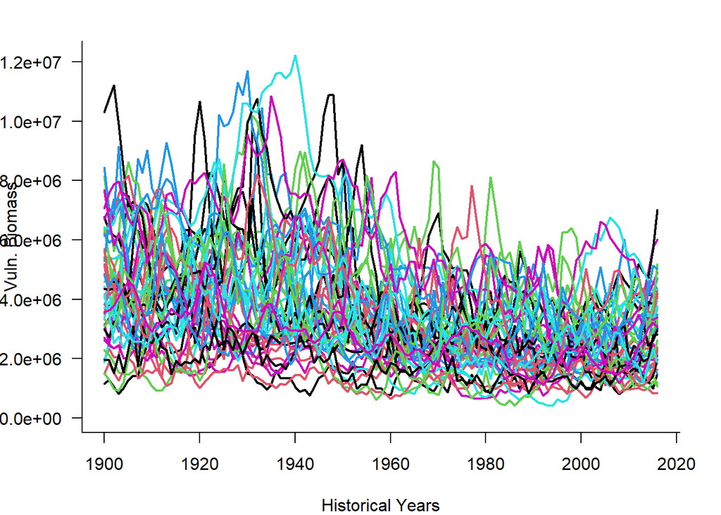

### Total Biomass

#### Depletion

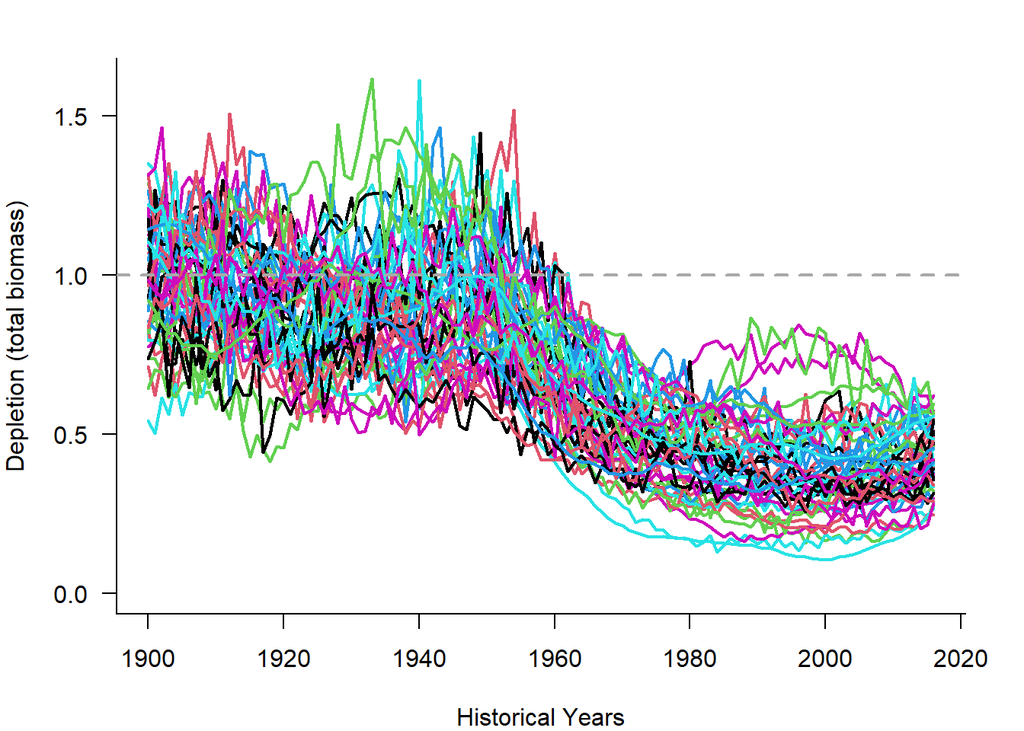

#### Absolute

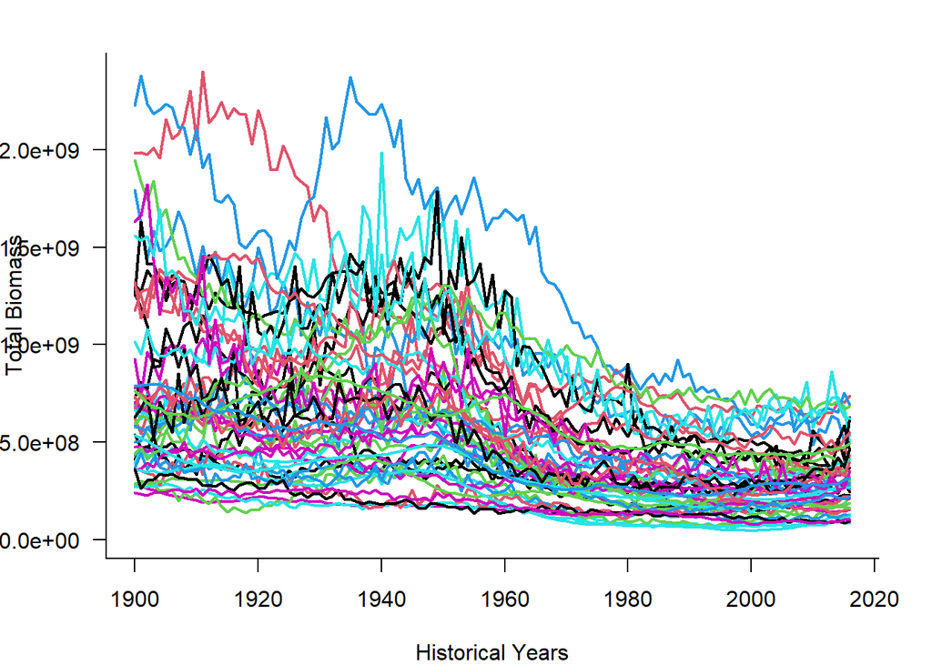

### Recruitment

#### Relative

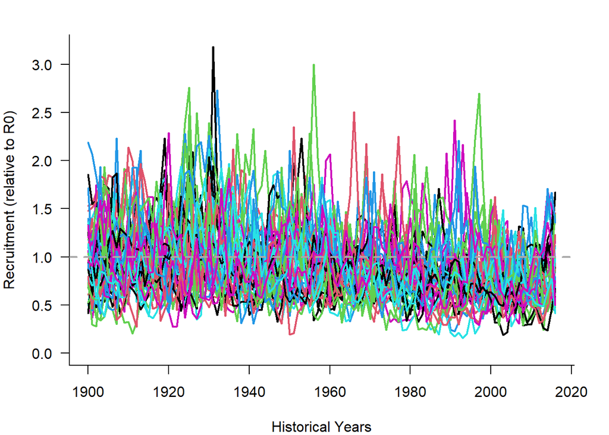

#### Absolute

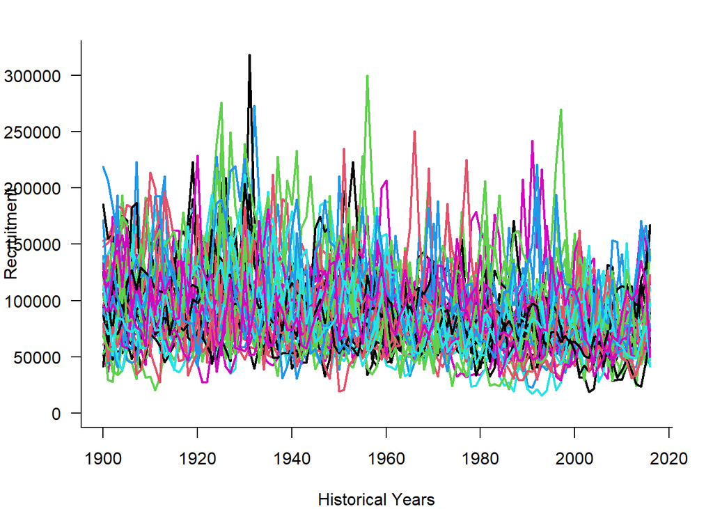

### Catch

#### Relative

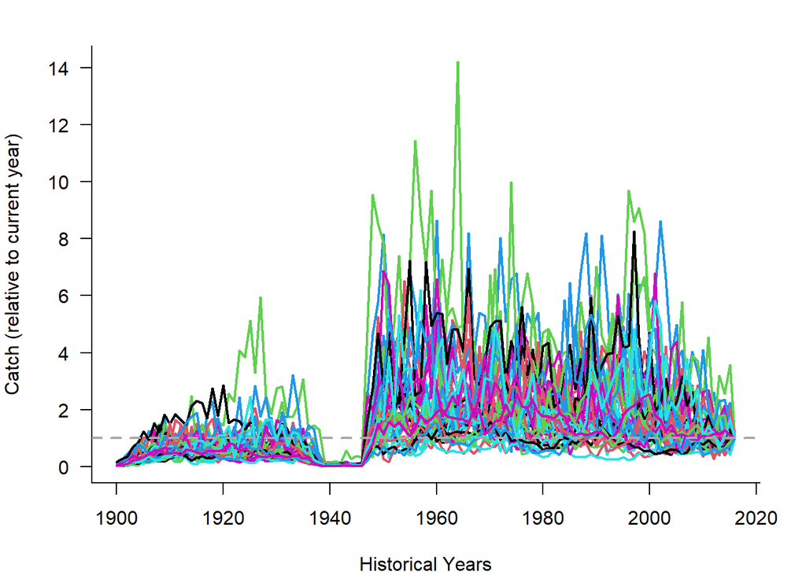

#### Absolute

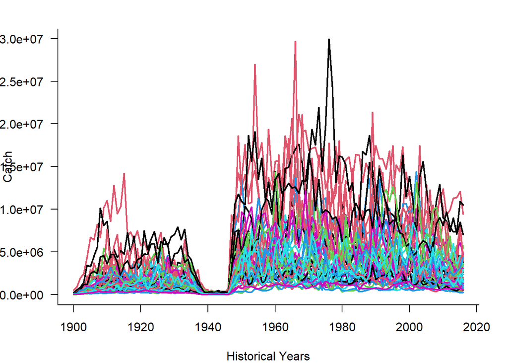

### Historical Fishing Mortality

#### Historical Time-Series

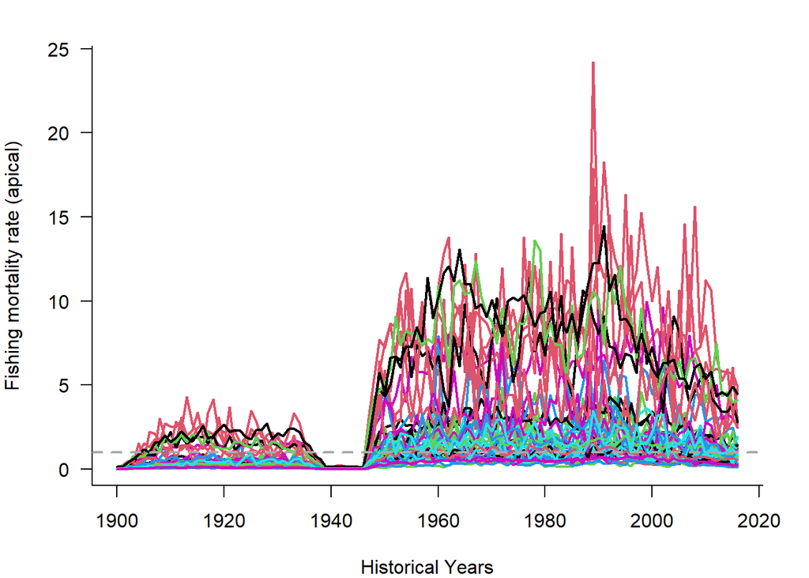

# References

Erisman, B.E., Allen, L.G., Claisse, J.T., Pondella II, D.J., Miller, E.F., and Murray, J.H. 2011. The illusion of plenty: hyperstability masks collapses in two recreational fisheries that target fish spawning aggregations. Can. J. Fish. Aquat. Sci. 68: 1705–1716. doi: 10.1139/F2011-090.

Hill, K.T., and Schneider, N. 1999. Historical Logbook Databases from California’s Commercial Passenger Fishing Vessel (Party boat) Fishery, 1936-1997. Scripps Inst. Oceanogr.: 1936–1997.

Jarvis, E.T., Gliniak, H.L., and Valle, C.F. 2014. Effects of fishing and the environment on the long-term sustainability of the recreational saltwater bass fishery in southern California. Calif. Fish Game 100: 234–259.

Love, M.S., Brooks, A., Busatto, D., Stephens, J., and Gregory, P.A. 1996. Aspects of life histories of kelp bass, Paralabrax clathratus, and the barred sand bass, P. nebulifer, from the southern California Bight. Fish. Bull. 94: 472–481.

Miller, E.F., Beck, D.S., and Dossett, W. 2008. Length-Weight Relationships of Select Common Nearshore Southern California Marine Fishes. Bull. South. Calif. Acad. Sci. 107: 183–186. doi:10.3160/0038-3872-107.3.183.

Myers, R.A., Barrowman, N.J., Hilborn, R., and Kehler, D.G. 2002. Inferring Bayesian Priors with Limited Direct Data: Applications to Risk Analysis. North Am. J. Fish. Manag. 22: 351–364.

Pauly, D. 1980. On the interrelationships between natural mortality, growth parameters, and mean environmental temperature in 175 fish stocks. J Cons Int. Explor Mer. 39: 175–192.